# Peer Assessment

Peer assessments are due by 6:00 PM on Saturday. The grading rubric is at the **bottom** of this notebook.

Do not use *Run All* to run the code cells. Run one code cell at a time by pressing `shift` + `enter`.

```python
from nose.tools import assert_equal, assert_true, assert_false
```

```python
%%bash
# make sandbox directory
mkdir -p ~/w6p1_testdir
wget -O /home/data_scientist/w6p1_testdir/crossword.jpg https://fosterdisbelief.files.wordpress.com/2015/11/crossword1.jpg
cp /etc/bash.bashrc ~/w6p1_testdir
```

```
--2016-11-29 22:21:17--  https://fosterdisbelief.files.wordpress.com/2015/11/crossword1.jpg
Resolving fosterdisbelief.files.wordpress.com (fosterdisbelief.files.wordpress.com)... 192.0.72.29, 192.0.72.28
Connecting to fosterdisbelief.files.wordpress.com (fosterdisbelief.files.wordpress.com)|192.0.72.29|:443... connected.
HTTP request sent, awaiting response... 200 OK
Length: 169036 (165K) [image/jpeg]
Saving to: ‘/home/data_scientist/w6p1_testdir/crossword.jpg’

     0K .......... .......... .......... .......... .......... 30% 2.37M 0s
    50K .......... .......... .......... .......... .......... 60% 10.7M 0s
   100K .......... .......... .......... .......... .......... 90%  169M 0s
   150K .......... .....                                      100% 4.08M=0.03s

2016-11-29 22:21:17 (5.55 MB/s) - ‘/home/data_scientist/w6p1_testdir/crossword.jpg’ saved [169036/169036]
```

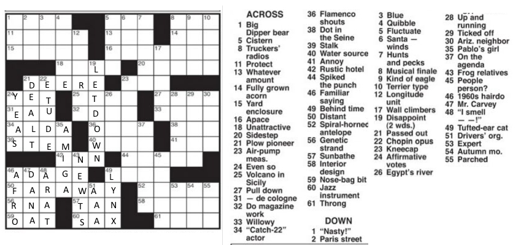

```python
from IPython.display import Image
Image(filename='/home/data_scientist/w6p1_testdir/crossword.jpg')
```

# Problem 1.

The main purpose of this problem is to give you experience with the tools you learned last week in conjunction with the tools you learned this week. The crossword puzzle above has some entries missing. We'll use regular expressions to help solve a couple of the missing entries. Write a bash script to do the following:

1. Go get a dictionary of english language words from [this link](http://www-01.sil.org/linguistics/wordlists/english/wordlist/wordsEn.txt)
2. Save the dictionary in ~/w6p1_testdir as `dictionary.txt`
3. 32 across (from the puzzle above) is a 4-letter word where the second letter is 'D'. Find all such words in the dictionary and save the output in ~/w6p1_testdir as `32_across.txt`.
4. The answer to 32 across is likely the word 'Edit'. 18 across is likely 'Ugly', which means 12 down is a 6-letter word of the form '??gre?'. Find all such words in the dictionary and save the output in ~/w6p1_testdir as `12_down.txt`

Ignore case as all words in the dictionary are lowercase.

**NOTE**: The `dictionary.txt` file includes a whitespace character trailing each line. You must consider this when constructing your regular expressions!

```python
%%bash
# Download the dictionary
wget -O ~/w6p1_testdir/dictionary.txt http://www-01.sil.org/linguistics/wordlists/english/wordlist/wordsEn.txt
# put an extra dot(.) to take the final space into account
grep -i '^.D...$' ~/w6p1_testdir/dictionary.txt > ~/w6p1_testdir/32_across.txt
grep -i '^..gre..$' ~/w6p1_testdir/dictionary.txt > ~/w6p1_testdir/12_down.txt
```

[output not shown]

```python
# dictionary.txt is in the right place
list_dir = !ls /home/data_scientist/w6p1_testdir/
assert_true('dictionary.txt' in list_dir)

words_32_across = !cat /home/data_scientist/w6p1_testdir/32_across.txt
# 32_across.txt is the right length
assert_equal(len(words_32_across), 28)
# a few select items are in 32_across.txt
assert_true('adam' in words_32_across)
assert_true('edit' in words_32_across)
assert_true('idea' in words_32_across)

words_12_down = !cat /home/data_scientist/w6p1_testdir/12_down.txt
# 32_across.txt is the right length
assert_equal(len(words_12_down), 3)
# a few select items are in 32_across.txt
assert_true('degree' in words_12_down)
assert_true('regret' in words_12_down)
assert_true('regrew' in words_12_down)
```

# Problem 2.

The main purpose of this problem is to give you experience constructing slightly more complicated regular expressions for a real-world purpose. There is a file in `/etc` called `bash.bashrc` that should be copied into your ~/w6p1_testdir. Suppose you want another copy of it, but you don't want any of the comments that come with it. Create two files in ~/w6p1_testdir:

1. All the commented lines in `/etc/bash.bashrc` as bashrc_comments.txt
2. All the non-commented lines **that are not whitespace** as bashrc_commands.txt

```python
%%bash
# match comments, note that there is an indented comment
grep -E '(^|^\s*)#' /etc/bash.bashrc >  ~/w6p1_testdir/bashrc_comments.txt
# match code by printing the previously unmatched results, note that there are empty lines to be removed
grep -vE '(^|^\s*)#' /etc/bash.bashrc | grep -vE '^$' >  ~/w6p1_testdir/bashrc_commands.txt
```

```python
# is everything where it's supposed to be?
files_in_testdir = !ls /home/data_scientist/w6p1_testdir/
assert_true('bashrc_comments.txt' in files_in_testdir)
assert_true('bashrc_commands.txt' in files_in_testdir)

# are the comments properly extracted?
comments = !cat /home/data_scientist/w6p1_testdir/bashrc_comments.txt
assert_equal(len(comments), 27)

# are the commands properly extracted
commands = !cat /home/data_scientist/w6p1_testdir/bashrc_commands.txt
assert_false("# check because c-n-f could've been removed in the meantime" in [x.strip() for x in commands])
assert_equal(len(commands), 20)
```

### Bonus

What if we wanted to run the commands in the newly created script? We can do so with the following:

```python
%%bash
cd ~/w6p1_testdir/
chmod u+x bashrc_commands.txt
source bashrc_commands.txt
```

# Problem 3.

The main purpose of this problem is to give you more exposure to constructing regular expressions. We return to the `bash.bashrc` file but this time we want to find all the conditional (`if` or `elif`) statements. Specifically, make the following inside of ~/w6p1_testdir:

1. A file `conditionals.txt` that contains all the `if` and `elif` statements in the `/etc/bash.bashrc` file.
2. A file `commented_conditionals.txt` that contains all the `if` and `elif` statements in `/etc/bash.bashrc` that have been commented out

You may wish to use the `-E` flag with `grep`.

```python
%%bash
# if statements starts with if/elif and ends with then
# match if statements in the commands file
grep 'if.*then$' ~/w6p1_testdir/bashrc_commands.txt > ~/w6p1_testdir/conditionals.txt
# match commented if statements and eliminate pure comments
grep -E '(^|^\s*)#\s*[e]{0,1}[l]{0,1}if.*then$' ~/w6p1_testdir/bash.bashrc > ~/w6p1_testdir/commented_conditionals.txt
```

```python
# did you find all the conditionals?
conditionals = !cat /home/data_scientist/w6p1_testdir/conditionals.txt
assert_equal(len(conditionals), 4)
assert_true("elif [ -x /usr/share/command-not-found/command-not-found ]; then" in [x.strip() for x in conditionals])

# did you find the correct commented conditionals?
commented_conditionals = !cat /home/data_scientist/w6p1_testdir/commented_conditionals.txt
assert_equal(len(commented_conditionals), 3)
assert_false("# if the command-not-found package is installed, use it" in [x.strip() for x in commented_conditionals])
```

## Cleaning Up

```python
rm -rf /home/data_scientist/w6p1_testdir/
```

## Just in Case

If you accidentally blow up your /etc/bash.bashrc, here it is:

```
# System-wide .bashrc file for interactive bash(1) shells.

# To enable the settings / commands in this file for login shells as well,
# this file has to be sourced in /etc/profile.

# If not running interactively, don't do anything
[ -z "$PS1" ] && return

# check the window size after each command and, if necessary,
# update the values of LINES and COLUMNS.
shopt -s checkwinsize

# set variable identifying the chroot you work in (used in the prompt below)
if [ -z "${debian_chroot:-}" ] && [ -r /etc/debian_chroot ]; then
    debian_chroot=$(cat /etc/debian_chroot)
fi

# set a fancy prompt (non-color, overwrite the one in /etc/profile)
PS1='${debian_chroot:+($debian_chroot)}\u@\h:\w\$ '

# Commented out, don't overwrite xterm -T "title" -n "icontitle" by default.
# If this is an xterm set the title to user@host:dir
#case "$TERM" in
#xterm*|rxvt*)
#    PROMPT_COMMAND='echo -ne "\033]0;${USER}@${HOSTNAME}: ${PWD}\007"'
#    ;;
#*)
#    ;;
#esac

# enable bash completion in interactive shells
#if ! shopt -oq posix; then
#  if [ -f /usr/share/bash-completion/bash_completion ]; then
#    . /usr/share/bash-completion/bash_completion
#  elif [ -f /etc/bash_completion ]; then
#    . /etc/bash_completion
#  fi
#fi

# if the command-not-found package is installed, use it
if [ -x /usr/lib/command-not-found -o -x /usr/share/command-not-found/command-not-found ]; then
    function command_not_found_handle {
            # check because c-n-f could've been removed in the meantime
                if [ -x /usr/lib/command-not-found ]; then
           /usr/lib/command-not-found -- "$1"
                   return $?
                elif [ -x /usr/share/command-not-found/command-not-found ]; then
           /usr/share/command-not-found/command-not-found -- "$1"
                   return $?
        else
           printf "%s: command not found\n" "$1" >&2
           return 127
        fi
    }
fi
```

# Peer Assessment

Run the following code cells to display the grading rubric for peer assessment. You must run both code cells. Do not use *Run All* to run the code cells. Run one code cell at a time by pressing `shift` + `enter`.

When there are no remaining tasks, press `Submit` in the *Assignments* tab. Your peer assessment is not submitted until you hit the `Submit` button.

```python
from IPython.display import display, Javascript
display(Javascript(
    '''
    var nb = IPython.notebook;
    var kernel = IPython.notebook.kernel;
    var command = "NOTEBOOK_NAME = '" + nb.notebook_path + "'";
    kernel.execute(command);
    '''
))
```

```python
from rubric import Rubric
r = Rubric(NOTEBOOK_NAME)
r.display_rubric()
```

```
Assessment Form

--------------------------------------------------------------------------------
Correctness | 0 points | Code does not run.
            | 2 points | Code runs, but does not produce correct output
            | 4 points | Code runs, produces correct output but output is difficult to understand.
            | 5 points | Code runs, produces correct output and output is easy to understand.

Type your score for correctness and press ENTER: 5
--------------------------------------------------------------------------------
Readability | 0 points | Code is not documented and is impossible to understand.
            | 2 points | Code is poorly documented, and uses non-recommended practices.
            | 4 points | Code is documented, but uses non-recommended practices
            | 5 points | Code is fully documented (as appropriate), and uses good programming practices.

Type your score for readability and press ENTER: 5
--------------------------------------------------------------------------------
Type any comments and press ENTER: Good
--------------------------------------------------------------------------------
Assessment saved. To change your assessment, simply run the code cell again.

Completed tasks
--------------------------------------------------------------------------------
amazing_snyder_9e5dd: Problem_3, Problem_2, Problem_1
elegant_mahavira_61cc6: Problem_3, Problem_2, Problem_1
high_shaw_6ebbe: Problem_2, Problem_1
hungry_mahavira_32d80: Problem_3, Problem_2, Problem_1
tender_hawking_e43a2: Problem_3, Problem_2, Problem_1
--------------------------------------------------------------------------------
Remaining tasks
--------------------------------------------------------------------------------
high_shaw_6ebbe: Problem_3
```